# regressionBasic

## Read data from scikit-learn

Definition of the data columns are in: https://scikit-learn.org/stable/datasets/toy_dataset.html#diabetes-dataset

Input data is already scaled.

```python
%matplotlib inline
import warnings
warnings.filterwarnings('ignore')

import numpy as np
import pandas as pd
import matplotlib.pyplot as plt
import seaborn as sns
from sklearn.datasets import load_diabetes
diabetes = load_diabetes()
print(diabetes.data.shape)
print(diabetes.data[0:5])
print(diabetes.target[0:5])
```

```
(442, 10)
[[ 0.03807591  0.05068012  0.06169621  0.02187235 -0.0442235  -0.03482076
  -0.04340085 -0.00259226  0.01990842 -0.01764613]
 [-0.00188202 -0.04464164 -0.05147406 -0.02632783 -0.00844872 -0.01916334
   0.07441156 -0.03949338 -0.06832974 -0.09220405]
 [ 0.08529891  0.05068012  0.04445121 -0.00567061 -0.04559945 -0.03419447
  -0.03235593 -0.00259226  0.00286377 -0.02593034]
 [-0.08906294 -0.04464164 -0.01159501 -0.03665645  0.01219057  0.02499059
  -0.03603757  0.03430886  0.02269202 -0.00936191]
 [ 0.00538306 -0.04464164 -0.03638469  0.02187235  0.00393485  0.01559614
   0.00814208 -0.00259226 -0.03199144 -0.04664087]]
[151.  75. 141. 206. 135.]
```

## Simple data exploration

1. Distribution of each feature and the target

|  | 0 | 1 | 2 | 3 | 4 | 5 | 6 | 7 | 8 | 9 |
| --- | --- | --- | --- | --- | --- | --- | --- | --- | --- | --- |
| count | 4.420000e+02 | 4.420000e+02 | 4.420000e+02 | 4.420000e+02 | 4.420000e+02 | 4.420000e+02 | 4.420000e+02 | 4.420000e+02 | 4.420000e+02 | 4.420000e+02 |
| mean | -3.634285e-16 | 1.308343e-16 | -8.045349e-16 | 1.281655e-16 | -8.835316e-17 | 1.327024e-16 | -4.574646e-16 | 3.777301e-16 | -3.830854e-16 | -3.412882e-16 |
| std | 4.761905e-02 | 4.761905e-02 | 4.761905e-02 | 4.761905e-02 | 4.761905e-02 | 4.761905e-02 | 4.761905e-02 | 4.761905e-02 | 4.761905e-02 | 4.761905e-02 |
| min | -1.072256e-01 | -4.464164e-02 | -9.027530e-02 | -1.123996e-01 | -1.267807e-01 | -1.156131e-01 | -1.023071e-01 | -7.639450e-02 | -1.260974e-01 | -1.377672e-01 |
| 25% | -3.729927e-02 | -4.464164e-02 | -3.422907e-02 | -3.665645e-02 | -3.424784e-02 | -3.035840e-02 | -3.511716e-02 | -3.949338e-02 | -3.324879e-02 | -3.317903e-02 |
| 50% | 5.383060e-03 | -4.464164e-02 | -7.283766e-03 | -5.670611e-03 | -4.320866e-03 | -3.819065e-03 | -6.584468e-03 | -2.592262e-03 | -1.947634e-03 | -1.077698e-03 |
| 75% | 3.807591e-02 | 5.068012e-02 | 3.124802e-02 | 3.564384e-02 | 2.835801e-02 | 2.984439e-02 | 2.931150e-02 | 3.430886e-02 | 3.243323e-02 | 2.791705e-02 |
| max | 1.107267e-01 | 5.068012e-02 | 1.705552e-01 | 1.320442e-01 | 1.539137e-01 | 1.987880e-01 | 1.811791e-01 | 1.852344e-01 | 1.335990e-01 | 1.356118e-01 |

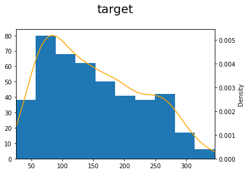

```python
data = pd.DataFrame(diabetes.data)
fig, ax1 = plt.subplots()
ax1.hist(diabetes.target, bins=10)
ax1.set_xlim((min(diabetes.target), max(diabetes.target)))
ax2 = ax1.twinx()
sns.kdeplot(diabetes.target, ax=ax2,color='orange')
ax1.set_title('target\n', fontsize = 20)
data.describe()
```

Separate into training and test sets:

```python
from sklearn.model_selection import train_test_split
x_train, x_test, y_train, y_test = train_test_split(diabetes.data,
                                diabetes.target, test_size=0.1, random_state=0)
print('training set: {0}，test set: {1}'.format(x_train.shape[0],
                                               x_test.shape[0]))
```

```
training set: 397，test set: 45
```

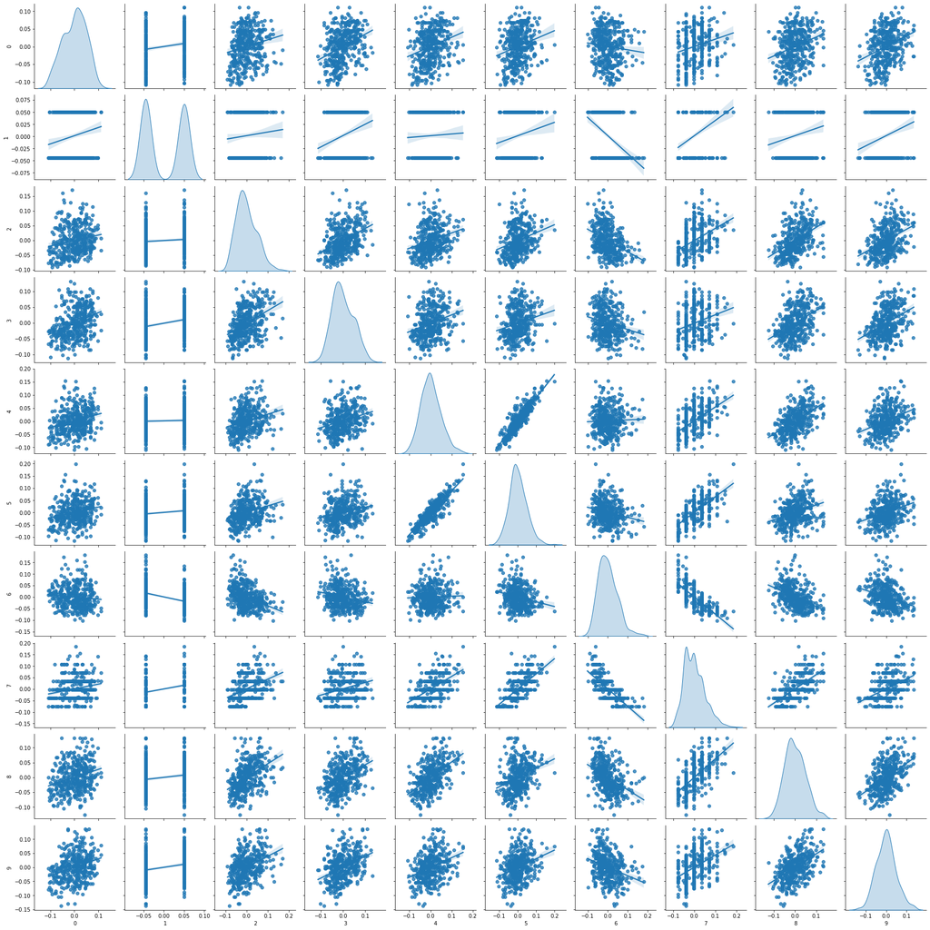

```python
sns.pairplot(pd.DataFrame(x_train), kind="reg", diag_kind="kde")
```

## Using scikit-learn to model in four steps

Step1: import package

```python
from sklearn.linear_model import LinearRegression
```

Step2: create model

```python
linearRegr = LinearRegression()
```

Step3: train model, inputs are training data and labels, outputs are model parameters:

```python
linearRegr.fit(x_train, y_train)
```

```
LinearRegression()
```

Step4: predict labels for new inputs:

```python
predictions = linearRegr.predict(x_test)
```

[output not shown]

## How to measure the quality of the prediction

### MSE

Most commonly used for regression is mean squared error $\text{MSE} = \cfrac{1}{N} \cdot \sum_i^N(y_i – \hat{y}_i)^2$

Pro: magnify and punish larger errors (where prediction is waaaayyy off from actual). Use when large errors are particularly undesirable. And MSE is differentiable (which is a very good property when the error is used for backpropagation in neural networks).

Contra: when data has outliers, MSE makes model more undesirable than it really is.

### RMSE

For reporting, because the unit of measurement of MSE is squared, we typically take the root, and report the root mean squared error (RMSE) instead:

$\text{RMSE} = \sqrt(\text{MSE})$

```python
from sklearn.metrics import mean_squared_error
mseError = mean_squared_error(y_test, predictions, squared=True)
rmseError = mean_squared_error(y_test, predictions, squared=False)
print('MSE is {:.2f}, RMSE is {:.2f}'.format(mseError, rmseError))
```

```
MSE is 3111.99, RMSE is 55.79
```

### MAE

Mean absolute error $\text{MAE} =\cfrac{1}{N} \cdot \sum_i^N \left|(y_i – \hat{y}_i) \right|$

Pro: it is linear to the difference between prediction and actual, therefore more intuitive. It is more robust to outliers.

Contra: it is not differentiable.

### MAPE

If it is more important to know the MAE proportional to the mean, we can use mean absolute percentage error $\text{MAPE} = \cfrac{1}{N} \cdot \sum_i^N \left|\cfrac{y_i – \hat{y}_i}{y_i} \right|$

Pro: it shows relative error to the mean.

Contra: it breaks when some actual values are zero. It is also biased when the actual value is very small. A more detailed comparison is here: https://www.statworx.com/at/blog/what-the-mape-is-falsely-blamed-for-its-true-weaknesses-and-better-alternatives/

Both MSE/RMSE and MAE/MAPE are lower the better.

A very good comparsion is here: https://medium.com/human-in-a-machine-world/mae-and-rmse-which-metric-is-better-e60ac3bde13d

```python
from sklearn.metrics import mean_absolute_error, mean_absolute_percentage_error
maeError = mean_absolute_error(y_test, predictions)
mapeError = mean_absolute_percentage_error(y_test, predictions)
print('MAE is {:.2f}, MAPE is {:.2f}'.format(maeError, mapeError))
```

```
MAE is 43.78, MAPE is 0.34
```

The coefficient of determination or R-squared: $R^2 = 1-\cfrac{\sum_i^N(y_i – \hat{y}_i)^2}{\sum_i^N(y_i – \bar{y}_i)^2}$, represents the proportion of explanable variance of the dependent variables (how much variance is explained by the linear regression model). It is bigger the better, meaning the regression model has taken into account a larger part of the variance.

Pro: it is proportional, therefore not affected by scaling. It is always between 0 and 1. Recommend to use when the data has a small mean but large skewness.

Contra: it is hard to explain to people. And it cannot be used for nonlinear regression. A good explanation here: https://stats.stackexchange.com/questions/359906/is-r-squared-truly-an-invalid-metric-for-non-linear-models

Adjusted R-squared: adjusted for small number of samples compared to the number of independent variables (a "fat" dataset). It can be used to determine if a feature is necessary. The value of Adjusted R-squared decreases if the increase in the R square by the additional variable isn’t significant enough.

```python
from sklearn.metrics import r2_score
r2Score = r2_score(y_test, predictions)
print('R2 is {:.2f}'.format(r2Score))
```

```
R2 is 0.36
```

### Spcial: measuring quality of forecast

When doing timeseries analysis, i.e., using historical data to predict the future, MAPE is very commonly used metric for its robustness when the actual data value varies. A very good comarison regarding timeseries regression metrics is here:

https://towardsdatascience.com/forecast-kpi-rmse-mae-mape-bias-cdc5703d242d

A comprehensive list of metrics in sklearn is here:

https://scikit-learn.org/stable/modules/classes.html#regression-metrics

## A little extra: about cross-validation

Overfitting: when sample data size is small and features are too many, the model may learn to perfectly fit the existing data and totally fail on new data.

There are ways to prevent overfitting, e.g., cross-validation, prunning in decision trees, dropout in neural networks, etc.

What we just did, to split into training and test set, is the **hold-out** method in cross validation.

Another common cross-validation method is **K-fold**. We divide the training set into portions, train on e.g., 9/10 th of the data and validate on the remaining 1 portion, and train again with different remaining portions. the model performance will be the average of the ten runs.

For classification problems, if the data has minority classes, we need to make sure that the minority classes are present in the training set. This is called the **stratified K-fold**. But since we are doing regression, we omit this part.

In sklearn, cross_val_score offers calculation of different metrics. Because sklearn in general maximizes scores, so in the cases of merics that need to be minimized, they add a negative sign in front of it. The actual score is just the positive version. Details here: https://scikit-learn.org/stable/modules/model_evaluation.html

A good overview here: https://www.analyticsvidhya.com/blog/2021/05/4-ways-to-evaluate-your-machine-learning-model-cross-validation-techniques-with-python-code/

At the end of this post, there is a very good discussion on bias-variance tradeoff of the cross-validation methods.

### Bias-variance tradeoff (optional)

Suppose we have a set of data from distribution $P(x,y)$ with the pattern (true function) $f(x)$ and a noise $\epsilon$ from a normal distribution of mean=0 and stddev=$\sigma$. We write it as $y=f(x)+\epsilon$. In a regression model, our goal is to find a $\hat{f}(x)$ such that the mean squared error between the estimate and the true value is minimized: MSE=$\mathbb{E}[(y-\hat{f}(x))^2]$.

Suppose the estimation function $\hat{f}$ is learned from training data set $D=\{(x_0,y_0),\cdots,(x_n,y_n)\}$ that is sampled from distribution $P(x,y)$, we therefore write this estimation function as $\hat{f}(x,D)$, $\hat{f}$ for short. We may have two problems with the learning algorithm: 1. parameters of $\hat{f}$ is very sensitive to the training data set, any small fluctuation in the training data set causes big change in the parameters. This is called **high variance**: instead of finding the pattern in training data, $\hat{f}$ learned the random noise (overfitting). 2. although the parameters of $\hat{f}$ is insensitive to training data set, the estimated value is far from the actual. This is called **high bias**: the learning algorithm fails to find relations between independent and target variables (underfitting).

There is obviously a tradeoff between bias and variance: when the bias of the estimator is high (for example always predicting the average of the target variable), the variance of the estimator's parameters across different training samples can be reduced (the average of target variable in each sample set is very similar, resulting in almost the same $\hat{f}(x,D)$ regardless of $D$).

Below the formal definition of bias and vaiance:

Bias $B=f-\mathbb{E}_D[\hat{f}]$ is how far the expected estimated value is from the true function. The *expected* value is the average across estimated values from different $\hat{f}$ learned from different training set samples $D$.

Variance $V=\mathbb{E}_D[(\mathbb{E}_D[\hat{f}]-\hat{f})^2]$ indicates the spread of different estimated functions from different training set samples $D$ (how far each estimated value is to the average estimate from all estimated functions).

With these definitions, we can rewrite the MSE into:

$\text{MSE}=\mathbb{E}_D[(y-\hat{f}(x,D))^2]=\mathbb{E}_D[(f+\epsilon-\hat{f})^2]=\mathbb{E}_D[(f+\epsilon-\hat{f}+\mathbb{E}_D[\hat{f}]-\mathbb{E}_D[\hat{f}])^2]\\ =\mathbb{E}_D[(B+(\mathbb{E}_D[\hat{f}]-\hat{f})+\epsilon)^2]\\ =\mathbb{E}_D[B^2+(\mathbb{E}_D[\hat{f}]-\hat{f})^2+\epsilon^2+2\epsilon B+2\epsilon (\mathbb{E}_D[\hat{f}]-\hat{f})+2B(\mathbb{E}_D[\hat{f}]-\hat{f})]\\ =\mathbb{E}_D[B^2] + V + \mathbb{E}_D[\epsilon^2] + 2\mathbb{E}_D[\epsilon B] + 2\mathbb{E}_D[\epsilon (\mathbb{E}_D[\hat{f}]-\hat{f})] + 2\mathbb{E}_D[B(\mathbb{E}_D[\hat{f}]-\hat{f})]$

We analyze the elements one by one:

1. $\mathbb{E}_D[B^2]=\mathbb{E}_D[f^2+(\mathbb{E}_D[\hat{f}])^2-2f\mathbb{E}_D[\hat{f}]]$

   Since the true function $f$ is independent of sampling $D$, $\mathbb{E}[f]=f,\mathbb{E}[f^2]=f^2$.

   Obviously, $\mathbb{E}[\mathbb{E}[\hat{f}]]=\mathbb{E}[\hat{f}],\mathbb{E}[(\mathbb{E}[\hat{f}])^2]=(\mathbb{E}[\hat{f}])^2$.

   Therefore $\mathbb{E}_D[B^2] = B^2$.
2. because $\epsilon$ is independent from $\hat{f}$, the expectation of the product of two random variables is equal to the product of two expectations: $\mathbb{E}[\epsilon (\mathbb{E}_D[\hat{f}]-\hat{f})]=\mathbb{E}[\epsilon]\mathbb{E}[(\mathbb{E}_D[\hat{f}]-\hat{f})]$, and because $\epsilon$ is a normal distribution with mean=0, $\mathbb{E}[\epsilon]=0$,

   Therefore $\mathbb{E}_D[\epsilon (\mathbb{E}_D[\hat{f}]-\hat{f})]=0$. For the same reason $\mathbb{E}_D[\epsilon B]=0$.
3. $\mathbb{E}_D[B(\mathbb{E}_D[\hat{f}]-\hat{f})]=\mathbb{E}[f\mathbb{E}[\hat{f}]-(\mathbb{E}[\hat{f}])^2-f\hat{f}+\mathbb{E}[\hat{f}]\hat{f}]=f\mathbb{E}[\hat{f}]-(\mathbb{E}[\hat{f}])^2-f\mathbb{E}[\hat{f}]+(\mathbb{E}[\hat{f}])^2=0$
4. since the variance of any random variable $\text{Var}(x)=\mathbb{E}[(x-\mathbb{E}[x])^2] = \mathbb{E}[x^2+(\mathbb{E}[x])^2-2x\mathbb{E}[x]]=\mathbb{E}[x^2] + (\mathbb{E}[x])^2 - 2(\mathbb{E}[x])^2$,

   we have $\text{Var}(\epsilon)=\mathbb{E}_D[\epsilon^2]-\mathbb{E}_D[\epsilon]^2=\mathbb{E}_D[\epsilon^2]=\sigma^2$.

To summarize:

$\text{MSE}=B^2+V+\sigma^2$

This is the bias and variance decomposition of MSE.

```python
from sklearn.model_selection import KFold, cross_val_score
kfold = KFold(n_splits=10)
cv_results = cross_val_score(linearRegr, x_train, y_train, cv=kfold, scoring='neg_mean_squared_error')
print('linear regression cross-validation mse: {:.2f}'.format(-cv_results.mean()))
```

```
linear regression cross-validation mse: 3034.82
```

## Some other regression algorithms

Ridge and Lasso reggression: r1 and r2 regulation: another way of preventing overfitting by penalizing large coefficients. Ridge adds the square of coefficients in cost function for minimization (r2 regularization), whereas Lasso adds the coefficients themselves (r1 regularization).

Difference in pratical use: Lasso can select features, making some coefficients zero. A very good explanation here:

https://towardsdatascience.com/ridge-and-lasso-regression-a-complete-guide-with-python-scikit-learn-e20e34bcbf0b

Another explanation from the perspective of bias vs. variance: https://www.geeksforgeeks.org/lasso-vs-ridge-vs-elastic-net-ml/

Rule-of-thumb: when you have features with small/medium sized effects, go with Ridge. If you have a lot of variables but only a few with a medium/large effect, go with Lasso. But when you only have a few variables anyway, you may want to use Ridge to keep them all in your models.

```python
from sklearn.linear_model import Ridge, Lasso
ridgeRegr = Ridge()
ridgeRegr.fit(x_train, y_train)
predictions_ridge = ridgeRegr.predict(x_test)
rmseError_ridge = mean_squared_error(y_test, predictions_ridge, squared=False)

lassoRegr = Lasso()
lassoRegr.fit(x_train, y_train)
predictions_lasso = lassoRegr.predict(x_test)
rmseError_lasso = mean_squared_error(y_test, predictions_lasso, squared=False)
print('Ridge RMSE is {:.2f}, Lasso RMSE is {:.2f}'.format(rmseError_ridge, rmseError_lasso))
```

```
Ridge RMSE is 57.77, Lasso RMSE is 61.02
```

XGboost: https://towardsdatascience.com/getting-started-with-xgboost-in-scikit-learn-f69f5f470a97

```python
from xgboost import XGBRegressor
xgbRegr = XGBRegressor()
xgbRegr.fit(x_train, y_train)
predictions = xgbRegr.predict(x_test)
rmseError = mean_squared_error(y_test, predictions, squared=False)
print('RMSE is {:.2f}'.format(rmseError))
```

```
RMSE is 61.55
```

Stochastic Gradient Descent:

https://towardsdatascience.com/step-by-step-tutorial-on-linear-regression-with-stochastic-gradient-descent-1d35b088a843

https://scikit-learn.org/stable/modules/sgd.html#:~:text=Stochastic%20Gradient%20Descent%20(SGD)%20is,Vector%20Machines%20and%20Logistic%20Regression.&text=The%20advantages%20of%20Stochastic%20Gradient,Efficiency.

```python
from sklearn.linear_model import SGDRegressor
sgdRegr = SGDRegressor()
sgdRegr.fit(x_train, y_train)
predictions = sgdRegr.predict(x_test)
rmseError = mean_squared_error(y_test, predictions, squared=False)
print('RMSE is {:.2f}'.format(rmseError))
```

```
RMSE is 58.36
```

Support vector machine for regression.

SVM is usually for classification. However, it is not impossible to use it for regression, too. See here:

https://towardsdatascience.com/an-introduction-to-support-vector-regression-svr-a3ebc1672c2

```python
from sklearn.svm import SVR
svrRegr = SVR()
svrRegr.fit(x_train, y_train)
predictions = svrRegr.predict(x_test)
rmseError = mean_squared_error(y_test, predictions, squared=False)
print('RMSE is {:.2f}'.format(rmseError))
```

```
RMSE is 67.62
```

Random forest for regression: through sample randomization and feature randomization, random forest is less prone to overfitting. More references here: https://stats.stackexchange.com/questions/36298/why-is-pruning-not-needed-for-random-forest-trees

For the same reasons, random forest usually does not require cross-validation to prevent overfitting. A related discussion here: https://datascience.stackexchange.com/questions/6510/does-modeling-with-random-forests-require-cross-validation

However, it does have generalization problems and problem with sparse data input, compared to e.g. linear regression models: https://medium.com/swlh/random-forest-fails-a8ca2d46c312

Parameters here: https://scikit-learn.org/stable/modules/generated/sklearn.ensemble.RandomForestRegressor.html

```python
from sklearn.ensemble import RandomForestRegressor
rfRegr = RandomForestRegressor()
rfRegr.fit(x_train, y_train)
predictions = rfRegr.predict(x_test)
rmseError = mean_squared_error(y_test, predictions, squared=False)
print('RMSE is {:.2f}'.format(rmseError))
```

```
RMSE is 59.92
```

Linear regression model comparison: https://towardsdatascience.com/choosing-a-scikit-learn-linear-regression-algorithm-dd96b48105f5

A little extra: forecasting and timeseries regression: there is a very good tutorial online from Hyndman: https://robjhyndman.com/teaching/

Although it's in R, the concepts are the same.